# Norm and RG binom models

Daniel Cohen

2026-03-23

```r
knitr::opts_chunk$set(error = TRUE)
```

For technical audiences only.

```r
## import and modify data
library(haven)
library(here)
library(haven)
library(dplyr)
setwd('/Users/danielcohen/Desktop/R_Code')
finalcoke <- read_sas("finalcoke", NULL)
finalcoke$MONTH <- as.factor(finalcoke$MONTH)
finalcoke$PATNO <- as.factor(finalcoke$PATNO)
finalcoke$TX_COND <- as.character(finalcoke$TX_COND)
finalcoke$TXNAME <- dplyr::recode(finalcoke$TX_COND,
                        "1" = "IDC",
                        "2" = "CT",
                        "3" = "SE",
                        "4" = "GDC")


timetxMeans <- finalcoke |> group_by(TXNAME, MONTH) |>
    select(DAYSUSED, PATNO, SITE, GENDER, BDI) |>
    mutate(mean_days = mean(DAYSUSED, na.rm = TRUE), sd_days = sd(DAYSUSED, na.rm = TRUE), meanbdi = mean(BDI, na.rm = TRUE) )
timetxMeans$logitmeandays <- log((timetxMeans$mean_days + .1)/(30.1-timetxMeans$mean_days))

timetxMeans$logitdays <- log((timetxMeans$DAYSUSED + 1)/(30.1-timetxMeans$DAYSUSED))


finalcoke$treated<- ifelse(test = finalcoke$MONTH == 0, yes = 0, no = 1)

finalcoke$postTreatTime <- ifelse(test = finalcoke$MONTH %in% c(0,1), yes = 0, no = as.numeric(finalcoke$MONTH) -1 )

finalcoke$timecombined = finalcoke$treated + finalcoke$postTreatTime

finalcoke$logit_days <- log((finalcoke$DAYSUSED +1) / (30 - finalcoke$DAYSUSED + 1))
finalcoke$log_days<- log(finalcoke$DAYSUSED + 1)
```

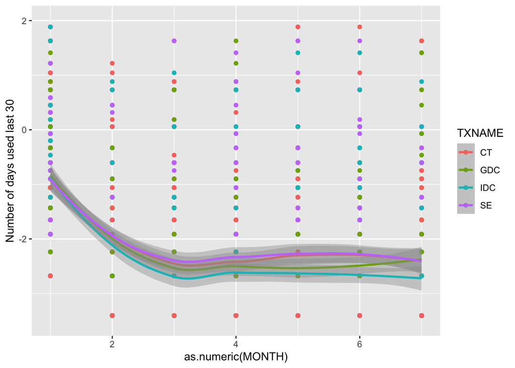

```r
library(ggplot2)
## plot data with LOESS
ggplot(data = timetxMeans, aes(x = as.numeric(MONTH),
                               y = logitdays, color = TXNAME)) +
    geom_point() +
    geom_smooth() +
    scale_y_continuous(limits = c(-3.5, 2) )
```

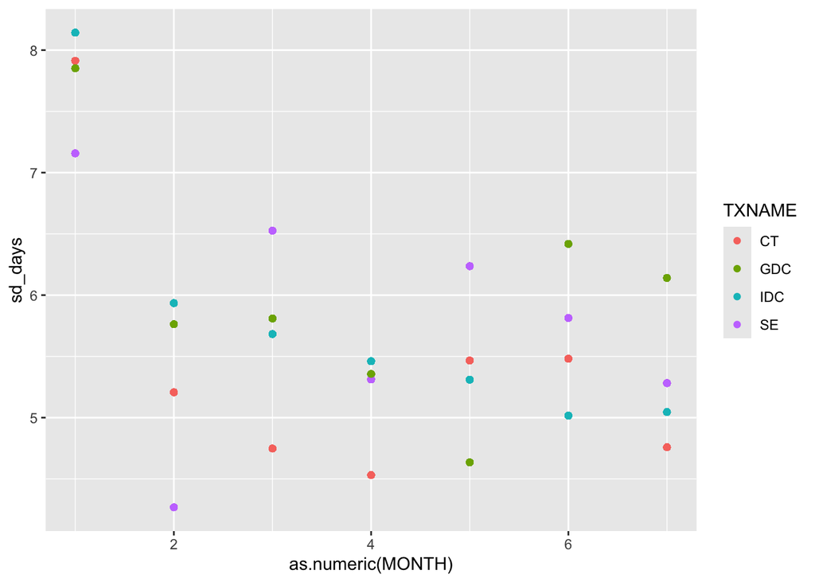

```r
## variance changes over time, no clear differences in treatment.
ggplot(data = timetxMeans, aes(x = as.numeric(MONTH),
                               y = sd_days, color = TXNAME)) +
    geom_point()
```

```r
## There's some difference in variance across sites. It really seems to be Mclean vs not.
library(dplyr)
siteMeans <- finalcoke |> group_by(SITE, MONTH) |>
    select(DAYSUSED, PATNO, SITE, GENDER) |>
    mutate(mean_days = mean(DAYSUSED, na.rm = TRUE), sd_days = sd(DAYSUSED, na.rm = TRUE))
```

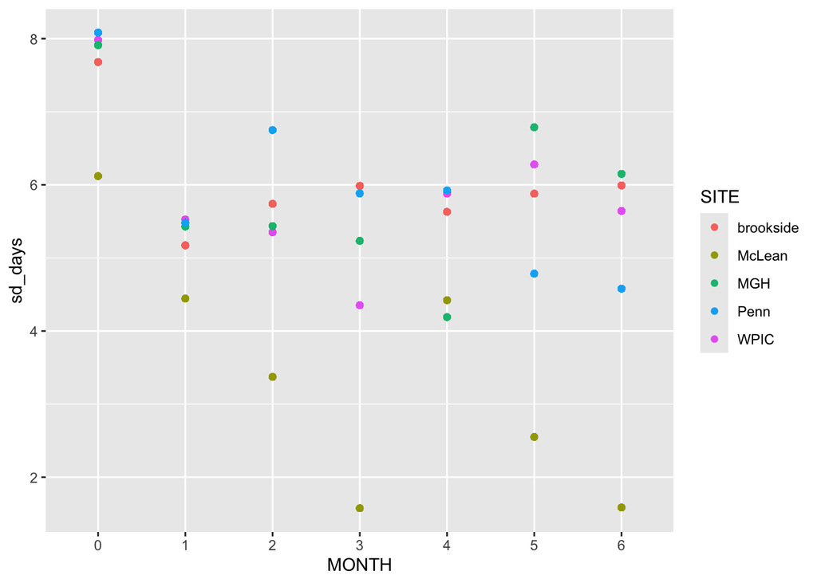

```r
ggplot(siteMeans, aes(x = MONTH, y = sd_days, color = SITE)) + geom_point()
```

```r
library(nlme)
# Full G Matrix has matrix error
norm_logit_fullg <- lme(
    logit_days ~ TXNAME * treated + TXNAME * postTreatTime + SITE,
    random = list(PATNO = pdSymm(~ postTreatTime + treated)),
    #correlation = corAR1(form = ~ as.numeric(MONTH) | PATNO),
    data = finalcoke,
    method = "REML", na.action = na.omit,
    control = lmeControl(maxiter = 1000, msMaxIter = 1000),
    weights = varIdent(form = ~1|treated)
)
intervals(norm_logit_fullg, which = "var-cov")
```

```
## Error in `intervals.lme()`:
## ! cannot get confidence intervals on var-cov components: Non-positive definite approximate variance-covariance
##  Consider 'which = "fixed"'
```

```r
# Uncorrelated G matrix converges
norm_logit_gonly <- lme(
    logit_days ~ TXNAME * treated + TXNAME * postTreatTime + SITE,
    random = list(PATNO = pdDiag(~ postTreatTime + treated)),
    #correlation = corAR1(form = ~ as.numeric(MONTH) | PATNO),
    data = finalcoke,
    method = "REML", na.action = na.omit,
    control = lmeControl(maxiter = 1000, msMaxIter = 1000),
    weights = varIdent(form = ~1|treated)
)
intervals(norm_logit_gonly, which = "var-cov")
```

```
## Approximate 95% confidence intervals
##
##  Random Effects:
##   Level: PATNO
##                        lower       est.     upper
## sd((Intercept))   0.58945335 0.68037377 0.7853182
## sd(postTreatTime) 0.04812146 0.07261958 0.1095894
## sd(treated)       0.61150797 0.71122289 0.8271977
##
##  Variance function:
##       lower      est.     upper
## 1 0.6374979 0.6969982 0.7620519
##
##  Within-group standard error:
##    lower     est.    upper
## 1.034822 1.121635 1.215732
```

```r
## Variance function is the percentage of variance that exists after treatment vs pre treatment
```

```r
##Try adding in Residual autocorrelation. No matrix error per se, but the intervals on PostTreatTime are absurdly wide, and may as well include 0.
norm_logit_rg_full<- lme(
    logit_days ~ TXNAME * treated + TXNAME * postTreatTime + SITE,
    random = list(PATNO = pdDiag(~postTreatTime + treated)),
    correlation = corAR1(form = ~ as.numeric(MONTH) | PATNO),
    data = finalcoke,
    method = "REML", na.action = na.omit,
    control = lmeControl(maxiter = 1000, msMaxIter = 1000),
    weights = varIdent(form = ~1|treated)
)
intervals(norm_logit_rg_full, which = "var-cov")
```

```
## Approximate 95% confidence intervals
##
##  Random Effects:
##   Level: PATNO
##                          lower         est.        upper
## sd((Intercept))   4.965845e-01 6.137566e-01 7.585761e-01
## sd(postTreatTime) 5.176810e-30 4.784375e-05 4.421690e+20
## sd(treated)       6.272718e-01 7.284498e-01 8.459477e-01
##
##  Correlation structure:
##          lower      est.     upper
## Phi1 0.2394343 0.3247595 0.4051067
##
##  Variance function:
##       lower      est.     upper
## 1 0.6598866 0.7264748 0.7997823
##
##  Within-group standard error:
##    lower     est.    upper
## 1.093971 1.188679 1.291587
```

```r
## Dropping the second random slope stabilizes intervals
norm_logit_rg_split<- lme(
    logit_days ~ TXNAME * treated + TXNAME * postTreatTime + SITE,
    random = list(PATNO = pdDiag(~treated)),
    correlation = corAR1(form = ~ as.numeric(MONTH) | PATNO),
    data = finalcoke,
    method = "REML", na.action = na.omit,
    control = lmeControl(maxiter = 1000, msMaxIter = 1000),
    weights = varIdent(form = ~1|treated)
)
intervals(norm_logit_rg_split, which = "var-cov")
```

```
## Approximate 95% confidence intervals
##
##  Random Effects:
##   Level: PATNO
##                     lower      est.     upper
## sd((Intercept)) 0.5106274 0.6137665 0.7377380
## sd(treated)     0.6310979 0.7284314 0.8407765
##
##  Correlation structure:
##          lower      est.     upper
## Phi1 0.2596108 0.3247853 0.3870146
##
##  Variance function:
##       lower     est.     upper
## 1 0.6685688 0.726473 0.7893922
##
##  Within-group standard error:
##    lower     est.    upper
## 1.098553 1.188696 1.286237
```

```r
## Having dropped the second random slope, we can estimate the correlation between intercepts and pre-post slopes. However, the confidence intervals on the variance function (pre vs post treat variance) and residual standard error are weird. What they are saying is that at month 0, there is no residual variance; it's entirely accounted for by the random intercepts, now that they can correlate with slopes.
norm_logit_rg_split_1corr<- lme(
    logit_days ~ TXNAME * treated + TXNAME * postTreatTime + SITE,
    random = list(PATNO = pdSymm(~treated)),
    correlation = corCAR1(form = ~ as.numeric(MONTH) | PATNO),
    data = finalcoke,
    method = "REML", na.action = na.omit,
    control = lmeControl(maxiter = 1000, msMaxIter = 1000),
    weights = varIdent(form = ~1|treated)
)
intervals(norm_logit_rg_split_1corr, which = "var-cov")
```

```
## Approximate 95% confidence intervals
##
##  Random Effects:
##   Level: PATNO
##                               lower      est.      upper
## sd((Intercept))           1.2257412  1.312061  1.4044594
## sd(treated)               1.1640400  1.262130  1.3684857
## cor((Intercept),treated) -0.8042252 -0.756376 -0.6987844
##
##  Correlation structure:
##        lower      est.     upper
## Phi 0.429302 0.4395992 0.4499486
##
##  Variance function:
##      lower     est.   upper
## 1 119213.8 450463.1 1702126
##
##  Within-group standard error:
##        lower         est.        upper
## 5.378663e-07 2.033803e-06 7.690302e-06
```

```r
## We see that dropping the heterogenous variance function results in significantly worse fit
norm_logit_rg_split_1corr_homovar<- lme(
    logit_days ~ TXNAME * treated + TXNAME * postTreatTime + SITE,
    random = list(PATNO = pdSymm(~treated)),
    correlation = corCAR1(form = ~ as.numeric(MONTH) | PATNO),
    data = finalcoke,
    method = "REML", na.action = na.omit,
    control = lmeControl(maxiter = 1000, msMaxIter = 1000)
)
print(anova(norm_logit_rg_split_1corr_homovar, norm_logit_rg_split_1corr))
```

```
##                                   Model df      AIC      BIC    logLik   Test
## norm_logit_rg_split_1corr_homovar     1 21 7758.372 7882.034 -3858.186
## norm_logit_rg_split_1corr             2 22 7738.454 7868.006 -3847.227 1 vs 2
##                                    L.Ratio p-value
## norm_logit_rg_split_1corr_homovar
## norm_logit_rg_split_1corr         21.91735  <.0001
```

```r
## We can also fit an unstructured variance covariance matrix on the R side. Needs to be in gls() for R matrix only
norm_logit_ronly_un<- gls(
    logit_days ~ TXNAME * treated + TXNAME * postTreatTime + SITE,
    correlation = corSymm(form = ~ as.numeric(MONTH) | PATNO),
    data = finalcoke,
    method = "REML", na.action = na.omit,
    control = lmeControl(maxiter = 1000, msMaxIter = 1000),
    weights = varIdent(form = ~1|treated)
)
print(intervals(norm_logit_ronly_un, which = "var-cov"))
```

```
## Approximate 95% confidence intervals
##
##  Correlation structure:
##              lower      est.     upper
## cor(1,2) 0.1884479 0.2814984 0.3695398
## cor(1,3) 0.1407033 0.2305455 0.3166218
## cor(1,4) 0.2233265 0.3132274 0.3978443
## cor(1,5) 0.1651757 0.2582957 0.3468512
## cor(1,6) 0.2265608 0.3159337 0.4000309
## cor(1,7) 0.1937444 0.2878007 0.3766145
## cor(2,3) 0.6216746 0.6813185 0.7331069
## cor(2,4) 0.5426669 0.6117225 0.6725642
## cor(2,5) 0.5480587 0.6198642 0.6826002
## cor(2,6) 0.5234617 0.5941228 0.6566675
## cor(2,7) 0.4382954 0.5205638 0.5941827
## cor(3,4) 0.6767836 0.7286042 0.7732402
## cor(3,5) 0.5186515 0.5878437 0.6493860
## cor(3,6) 0.4515855 0.5277328 0.5962479
## cor(3,7) 0.4110625 0.4934012 0.5677545
## cor(4,5) 0.7134308 0.7598721 0.7996671
## cor(4,6) 0.4858170 0.5603098 0.6267216
## cor(4,7) 0.3870309 0.4725610 0.5500284
## cor(5,6) 0.6443471 0.7006305 0.7493644
## cor(5,7) 0.4279413 0.5092625 0.5824042
## cor(6,7) 0.6379245 0.6953481 0.7450820
##
##  Variance function:
##     lower      est.    upper
## 1 0.89907 0.9783008 1.064514
##
##  Residual standard error:
##    lower     est.    upper
## 1.220958 1.312411 1.410715
```

```r
## Finally, we can try adding a random intercept to the unstructured model, but it can't get a stable matrix. I tested without heterogenous variance, still didn't work
norm_logit_un_int<- lme(
    logit_days ~ TXNAME * treated + TXNAME * postTreatTime + SITE,
    correlation = corSymm(form = ~ as.numeric(MONTH) | PATNO),
    random = list(PATNO = ~ 1),
    data = finalcoke,
    method = "REML", na.action = na.omit,
    control = lmeControl(maxiter = 1000, msMaxIter = 1000),
    weights = varIdent(form = ~1|treated)
)
intervals(norm_logit_un_int, which = "var-cov")
```

```
## Error in `intervals.lme()`:
## ! cannot get confidence intervals on var-cov components: Non-positive definite approximate variance-covariance
##  Consider 'which = "fixed"'
```

```r
#Lets compare the best G only, the best RG, and the best R only:
#The unstructured model fits better than the RG model by AIC and LRT but not BIC.
# It didn't really tell a different story than the RG model, saying that between the pre treatment month and all others was low correlation, but among the post treatment months, it looked like an ar(1) matrix.
# So I think we're fine picking the more parsinominous RG model
print(anova(norm_logit_gonly, norm_logit_rg_split_1corr, norm_logit_ronly_un))
```

```
##                           Model df      AIC      BIC    logLik   Test   L.Ratio
## norm_logit_gonly              1 21 7868.695 7992.358 -3913.348
## norm_logit_rg_split_1corr     2 22 7738.454 7868.006 -3847.227 1 vs 2 132.24125
## norm_logit_ronly_un           3 39 7734.124 7963.783 -3828.062 2 vs 3  38.33058
##                           p-value
## norm_logit_gonly
## norm_logit_rg_split_1corr  <.0001
## norm_logit_ronly_un        0.0022
```

```r
best_normal_model <- norm_logit_rg_split_1corr
```

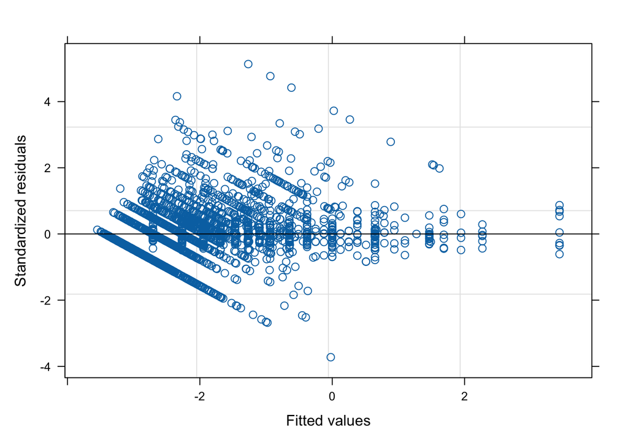

```r
#Lets run diagnostics on the model:
plot(best_normal_model)
```

```r
## Some pretty severe unmodeled heteroskedasticity.
## We can clearly see how the line passes through the discrete distribution at a 30 degreeish angle, inducing heteroskedasticity. I don't think there's really a way around this.
```

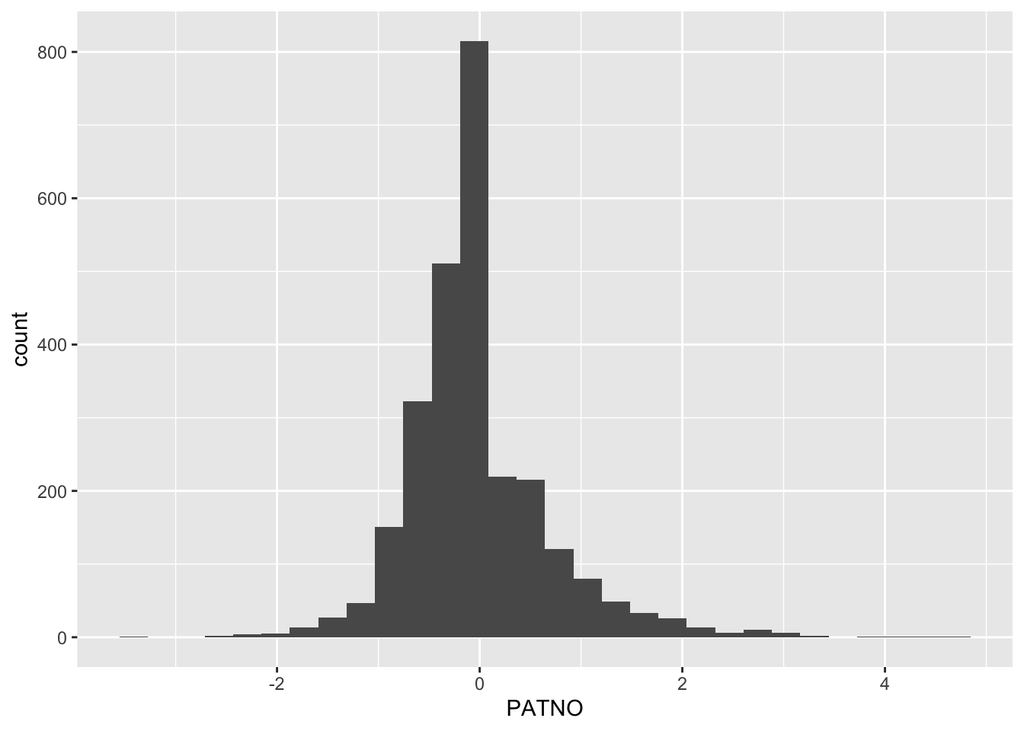

```r
residuals <- as.data.frame(best_normal_model$residuals)
ggplot(data = residuals, aes(x = PATNO)) + geom_histogram()
```

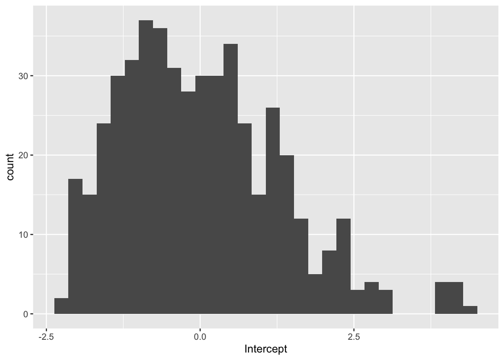

```r
ranefs <- as.data.frame(ranef(best_normal_model))
ranefs <- ranefs %>% rename_at(1, ~'Intercept')
ggplot(data = ranefs, aes(x = Intercept)) + geom_histogram()
```

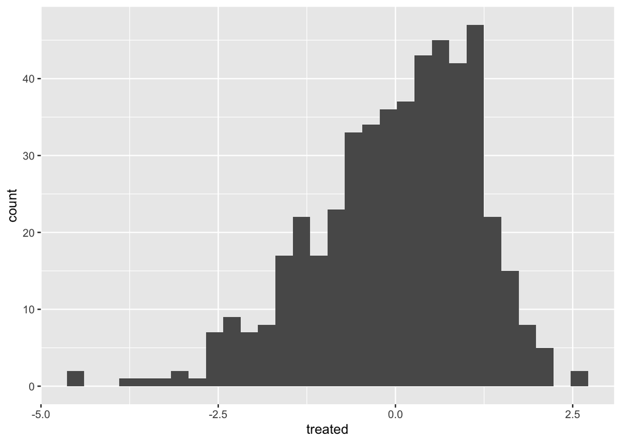

```r
ggplot(data = ranefs, aes(x = treated)) + geom_histogram()
```

```r
##  We see that with containment degrees of freedom, we still don't reach statistical significance. I doubt that with kenward rogers ddfm that we'd still be at alpha = .10
print(anova(norm_logit_rg_split_1corr))
```

```
##                      numDF denDF   F-value p-value
## (Intercept)              1  2188 1574.2793  <.0001
## TXNAME                   3   479    0.5576  0.6433
## treated                  1  2188  652.0638  <.0001
## postTreatTime            1  2188   12.4636  0.0004
## SITE                     4   479    1.9482  0.1013
## TXNAME:treated           3  2188    2.2595  0.0796
## TXNAME:postTreatTime     3  2188    0.7603  0.5163
```

```r
## Checking tukey adjusted means anyway, on containment df we see no significant differences, which would be true under KR degrees of freedom as well.
library(emmeans)
normtrends1 <- emtrends(best_normal_model, ~TXNAME, var ="treated")
normtrends1
```

```
##  TXNAME treated.trend    SE   df lower.CL upper.CL
##  CT             -1.30 0.147 2188    -1.59    -1.01
##  GDC            -1.62 0.146 2188    -1.91    -1.34
##  IDC            -1.71 0.149 2188    -2.00    -1.42
##  SE             -1.41 0.145 2188    -1.69    -1.13
##
## Results are averaged over the levels of: treated, SITE
## Degrees-of-freedom method: containment
## Confidence level used: 0.95
```

```r
pairs(normtrends1)
```

```
##  contrast  estimate    SE   df t.ratio p.value
##  CT - GDC    0.3231 0.207 2188   1.562  0.4007
##  CT - IDC    0.4099 0.209 2188   1.961  0.2031
##  CT - SE     0.1111 0.206 2188   0.539  0.9496
##  GDC - IDC   0.0869 0.208 2188   0.418  0.9755
##  GDC - SE   -0.2120 0.205 2188  -1.033  0.7301
##  IDC - SE   -0.2988 0.207 2188  -1.441  0.4739
##
## Results are averaged over the levels of: treated, SITE
## Degrees-of-freedom method: containment
## P value adjustment: tukey method for comparing a family of 4 estimates
```

```r
normtrends2 <- emtrends(best_normal_model, ~TXNAME, var ="postTreatTime")
normtrends2
```

```
##  TXNAME postTreatTime.trend     SE   df lower.CL upper.CL
##  CT                 -0.0560 0.0215 2188  -0.0983  -0.0138
##  GDC                -0.0218 0.0215 2188  -0.0640   0.0203
##  IDC                -0.0542 0.0223 2188  -0.0980  -0.0104
##  SE                 -0.0228 0.0217 2188  -0.0654   0.0197
##
## Results are averaged over the levels of: treated, SITE
## Degrees-of-freedom method: containment
## Confidence level used: 0.95
```

```r
pairs(normtrends2)
```

```
##  contrast  estimate     SE   df t.ratio p.value
##  CT - GDC  -0.03422 0.0304 2188  -1.125  0.6743
##  CT - IDC  -0.00185 0.0310 2188  -0.060  0.9999
##  CT - SE   -0.03322 0.0306 2188  -1.087  0.6978
##  GDC - IDC  0.03237 0.0310 2188   1.044  0.7234
##  GDC - SE   0.00100 0.0305 2188   0.033  1.0000
##  IDC - SE  -0.03137 0.0311 2188  -1.007  0.7451
##
## Results are averaged over the levels of: treated, SITE
## Degrees-of-freedom method: containment
## P value adjustment: tukey method for comparing a family of 4 estimates
```

```r
summary(best_normal_model)
```

```
## Linear mixed-effects model fit by REML
##   Data: finalcoke
##        AIC      BIC    logLik
##   7738.454 7868.006 -3847.227
##
## Random effects:
##  Formula: ~treated | PATNO
##  Structure: General positive-definite
##             StdDev       Corr
## (Intercept) 1.312061e+00 (Intr)
## treated     1.262130e+00 -0.756
## Residual    2.033803e-06
##
## Correlation Structure: Continuous AR(1)
##  Formula: ~as.numeric(MONTH) | PATNO
##  Parameter estimate(s):
##       Phi
## 0.4395992
## Variance function:
##  Structure: Different standard deviations per stratum
##  Formula: ~1 | treated
##  Parameter estimates:
##        0        1
##      1.0 450463.1
## Fixed effects:  logit_days ~ TXNAME * treated + TXNAME * postTreatTime + SITE
##                              Value  Std.Error   DF   t-value p-value
## (Intercept)             -0.8001002 0.14249388 2188 -5.614980  0.0000
## TXNAMEGDC                0.2078042 0.16871224  479  1.231708  0.2187
## TXNAMEIDC                0.1658821 0.16942227  479  0.979105  0.3280
## TXNAMESE                 0.0405663 0.16838387  479  0.240916  0.8097
## treated                 -1.2999604 0.14697680 2188 -8.844664  0.0000
## postTreatTime           -0.0560352 0.02153419 2188 -2.602153  0.0093
## SITEMcLean              -0.3237548 0.16565706  479 -1.954367  0.0512
## SITEMGH                  0.1413288 0.14330505  479  0.986209  0.3245
## SITEPenn                 0.0474311 0.12493375  479  0.379650  0.7044
## SITEWPIC                -0.0760227 0.12411812  479 -0.612503  0.5405
## TXNAMEGDC:treated       -0.3230708 0.20682166 2188 -1.562074  0.1184
## TXNAMEIDC:treated       -0.4099252 0.20899160 2188 -1.961443  0.0500
## TXNAMESE:treated        -0.1111045 0.20623742 2188 -0.538721  0.5901
## TXNAMEGDC:postTreatTime  0.0342178 0.03042333 2188  1.124723  0.2608
```

[output cut: 43 more lines]

```
## SITEPenn
## SITEWPIC
## TXNAMEGDC:treated
## TXNAMEIDC:treated
## TXNAMESE:treated
## TXNAMEGDC:postTreatTime -0.243
## TXNAMEIDC:postTreatTime -0.238      0.491
## TXNAMESE:postTreatTime  -0.480      0.499       0.489
##
## Standardized Within-Group Residuals:
##        Min         Q1        Med         Q3        Max
## -3.7241894 -0.4657130 -0.1402118  0.3421517  5.1329305
##
## Number of Observations: 2683
## Number of Groups: 487
```

```r
intervals(best_normal_model)
```

```
## Approximate 95% confidence intervals
##
##  Fixed effects:
##                               lower         est.         upper
## (Intercept)             -1.07953768 -0.800100230 -5.206628e-01
## TXNAMEGDC               -0.12370332  0.207804238  5.393118e-01
## TXNAMEIDC               -0.16702058  0.165882122  4.987848e-01
## TXNAMESE                -0.29029601  0.040566324  3.714287e-01
## treated                 -1.58818906 -1.299960390 -1.011732e+00
## postTreatTime           -0.09826485 -0.056035250 -1.380565e-02
## SITEMcLean              -0.64925912 -0.323754773  1.749573e-03
## SITEMGH                 -0.14025544  0.141328793  4.229130e-01
## SITEPenn                -0.19805486  0.047431081  2.929170e-01
## SITEWPIC                -0.31990598 -0.076022703  1.678606e-01
## TXNAMEGDC:treated       -0.72865818 -0.323070825  8.251653e-02
## TXNAMEIDC:treated       -0.81976794 -0.409925212 -8.247976e-05
## TXNAMESE:treated        -0.51554617 -0.111104519  2.933371e-01
## TXNAMEGDC:postTreatTime -0.02544381  0.034217814  9.387944e-02
## TXNAMEIDC:postTreatTime -0.05899148  0.001850669  6.269282e-02
## TXNAMESE:postTreatTime  -0.02672941  0.033217672  9.316475e-02
##
##  Random Effects:
##   Level: PATNO
##                               lower      est.      upper
## sd((Intercept))           1.2257412  1.312061  1.4044594
## sd(treated)               1.1640400  1.262130  1.3684857
## cor((Intercept),treated) -0.8042252 -0.756376 -0.6987844
##
##  Correlation structure:
##        lower      est.     upper
## Phi 0.429302 0.4395992 0.4499486
##
##  Variance function:
##      lower     est.   upper
## 1 119213.8 450463.1 1702126
##
##  Within-group standard error:
##        lower         est.        upper
## 5.378663e-07 2.033803e-06 7.690302e-06
```

Moving onto modeling this with logistic regression in glmmTMB(). A few notes beforehand. First, glmmTMB() does not calculate denominator degrees of freedom, just using χ squared and z tests rather than F and t tests, respectively. However, the F and t distributions converge to the Χ squared and normal distributions with increasing (denominator) degrees of freedom. The p values at 120 df for F and t are extremely similar to those at infinite df (fully converged), and so with a minimum of 300 ddf, we should be fine.

Second, because logit links are far more common and interpretable to the intended audience as well as a general, as well as for space purposes, I won’t be showing the probit and complementary log log links here. In testing elsewhere, I found that the probit link fit significantly worse(deviance ~ 200 larger), while the cloglog link fit significantly better than logit(deviance ~ 20 smaller), but conclusions did not differ with the cloglog link.

Third, I am modeling the number of days used as a series of 30 independent trials here, where the prediction is a percentage chance of using cocaine on a particular day, independent of whether the patient used on other days. It is obviously false that for a given patient, conditional on their random effects, that the trials are not independent, due to the common binge-relapse cycle across addictions. This will be handled in several ways, depending on the model. In models with only G random effects, this will be handled by the use of the β - binomial distribution, where p (the probability of “success”, here using drugs) is not treated as a constant for a given subject, but itself on a β - distribution with bounds (0,1). This is similar to the negative binomial extension to the Poisson distribution (or the Bayesian prior distribution of p for a plain binomial), and provides the added variance necessary to model correlated outcomes. The mean variance relationship in the β binomial distribution is V=μ(1−μ)(n(ϕ+n)/(ϕ+1)). Models using R matrices did not converge on the β binomial distribution, but did on the plain binomial distribution, with comparable fit statistics to the β-binomial G models. The R matrix therefore appears to capture the same over-dispersion that the β binomial model does.

Finally, I will use the packages DHARMa and performance to do residual diagnostics on the selected model.

```r
library(glmmTMB)
## A correlated G matrix does not converge, and we see the issue is the correlations
betabinom_gfull <- glmmTMB(cbind(DAYSUSED, 30 - DAYSUSED) ~ TXNAME * (treated + postTreatTime ) + SITE +  (treated + postTreatTime| PATNO), data = finalcoke, family = betabinomial(link = "logit"), dispformula = ~treated, REML = TRUE)
confint(betabinom_gfull, parm = "theta_")
```

```
##                                          2.5 %    97.5 %   Estimate
## Std.Dev.(Intercept)|PATNO           0.24724754 0.4621890  0.3380460
## Std.Dev.treated|PATNO               1.10887901 1.3293296  1.2141111
## Std.Dev.postTreatTime|PATNO         0.08590831 0.1853359  0.1261820
## Cor.treated.(Intercept)|PATNO               NA        NA  0.8434742
## Cor.postTreatTime.(Intercept)|PATNO         NA        NA  0.3312739
## Cor.postTreatTime.treated|PATNO             NA        NA -0.2274136
```

```r
confint(betabinom_gfull, parm = "disp_")
```

```
##                      2.5 %   97.5 %  Estimate
## disp.(Intercept) 1.0763240 1.355647 1.2159854
## disp.treated     0.5951087 0.977025 0.7860668
```

```r
## an uncorrelated G matrix produces stable estimates for random slopes and intercepts, unlike the normal model
betabinom_g_uncorr <- glmmTMB(cbind(DAYSUSED, 30 - DAYSUSED) ~ TXNAME * (treated + postTreatTime ) + SITE +  (treated + postTreatTime|| PATNO), data = finalcoke, family = betabinomial(link = "logit"), dispformula = ~treated, REML = TRUE)
confint(betabinom_g_uncorr, parm = "theta_")
```

```
##                                 2.5 %    97.5 %  Estimate
## Std.Dev.(Intercept)|PATNO   0.4725237 0.8020095 0.6156042
## Std.Dev.treated|PATNO       1.1406835 1.4759353 1.2975265
## Std.Dev.postTreatTime|PATNO 0.0689180 0.1841148 0.1126447
```

```r
confint(betabinom_g_uncorr, parm = "disp_")
```

```
##                      2.5 %    97.5 % Estimate
## disp.(Intercept) 1.2419339 1.7617849 1.501859
## disp.treated     0.1899898 0.7660662 0.478028
```

```r
## Next, the previous model with autocorrelated residuals. Note that we have to set dispformula = 0 + treated for internal reasons. However, it doesn't converge, as I mentioned would happen:
betabinom_rg_ar1 <- glmmTMB(cbind(DAYSUSED, 30 - DAYSUSED) ~ TXNAME * (treated + postTreatTime ) + SITE +  (treated + postTreatTime|| PATNO) + ar1(0 + MONTH| PATNO), data = finalcoke, family = betabinomial(link = "logit"), dispformula = ~0 + treated, REML = TRUE)
confint(betabinom_rg_ar1, parm = "theta_")
```

```
##                                  2.5 %    97.5 %     Estimate
## Std.Dev.(Intercept)|PATNO   0.00000000       Inf 2.813626e-05
## Std.Dev.treated|PATNO       1.34932656 1.6510072 1.492564e+00
## Std.Dev.postTreatTime|PATNO 0.07327456 0.1874354 1.171932e-01
## Std.Dev.MONTH0|PATNO.1      0.00000000       Inf 7.524416e-05
## Std.Dev.MONTH1|PATNO.1      0.00000000       Inf 7.524416e-05
```

```r
confint(betabinom_rg_ar1, parm = "disp_")
```

```
##                 2.5 %   97.5 % Estimate
## disp.treated 1.857023 2.114386 1.985704
```

```r
## We can try shifting to a plain binomial, which does converge. In an omitted model, the correlations between slopes and intercepts did not converge.

binom_rg_ar1 <- glmmTMB(cbind(DAYSUSED, 30 - DAYSUSED) ~ TXNAME * (treated + postTreatTime) + SITE +  (treated + postTreatTime|| PATNO) + ar1(0 + MONTH| PATNO), data = finalcoke, family = binomial(link = "logit"), REML = TRUE)
summary(binom_rg_ar1)
```

```
##  Family: binomial  ( logit )
## Formula:
## cbind(DAYSUSED, 30 - DAYSUSED) ~ TXNAME * (treated + postTreatTime) +
##     SITE + (treated + postTreatTime || PATNO) + ar1(0 + MONTH |      PATNO)
## Data: finalcoke
##
##       AIC       BIC    logLik -2*log(L)  df.resid
##   11629.3   11753.1   -5793.7   11587.3      2662
##
## Random effects:
##
## Conditional model:
##  Groups  Name          Variance Std.Dev. Corr
##  PATNO   (Intercept)   0.5981   0.7734
##          treated       2.6930   1.6410
##          postTreatTime 0.0346   0.1860
##  PATNO.1 MONTH0        1.5238   1.2344   0.41 (ar1)
## Number of obs: 2683, groups:  PATNO, 487
##
## Conditional model:
##                         Estimate Std. Error z value Pr(>|z|)
## (Intercept)             -0.80379    0.17751  -4.528 5.95e-06 ***
## TXNAMEGDC                0.21071    0.19690   1.070  0.28456
## TXNAMEIDC                0.16092    0.19806   0.812  0.41651
## TXNAMESE                 0.06081    0.19647   0.309  0.75694
## treated                 -1.77456    0.22781  -7.790 6.73e-15 ***
## postTreatTime           -0.10881    0.04188  -2.598  0.00938 **
## SITEMcLean              -0.36215    0.23725  -1.526  0.12689
## SITEMGH                  0.10330    0.20538   0.503  0.61500
## SITEPenn                -0.05881    0.17858  -0.329  0.74190
## SITEWPIC                -0.21381    0.17770  -1.203  0.22891
## TXNAMEGDC:treated       -0.46721    0.32399  -1.442  0.14929
## TXNAMEIDC:treated       -0.60893    0.33045  -1.843  0.06537 .
## TXNAMESE:treated        -0.13409    0.31946  -0.420  0.67467
## TXNAMEGDC:postTreatTime  0.04934    0.05998   0.823  0.41079
## TXNAMEIDC:postTreatTime -0.03843    0.06276  -0.612  0.54035
## TXNAMESE:postTreatTime   0.05033    0.05911   0.851  0.39451
## ---
## Signif. codes:  0 '***' 0.001 '**' 0.01 '*' 0.05 '.' 0.1 ' ' 1
```

```r
## We can also fit a correlated G matrix to a plain binomial model, but it will fit extremely poorly compared to others.
binom_gfull <- glmmTMB(cbind(DAYSUSED, 30 - DAYSUSED) ~ TXNAME * (treated + postTreatTime) + SITE +  (treated + postTreatTime| PATNO), data = finalcoke, family = binomial(link = "logit"), REML = TRUE)
confint(binom_gfull, parm = "theta_")
```

```
##                                           2.5 %     97.5 %    Estimate
## Std.Dev.(Intercept)|PATNO            1.28042366  1.4939219  1.38305929
## Std.Dev.treated|PATNO                2.21823864  2.7296174  2.46067934
## Std.Dev.postTreatTime|PATNO          0.37667926  0.4709997  0.42120758
## Cor.treated.(Intercept)|PATNO       -0.41030844 -0.2017107 -0.31160729
## Cor.postTreatTime.(Intercept)|PATNO -0.09586607  0.1488151  0.01657987
## Cor.postTreatTime.treated|PATNO     -0.55254971 -0.4493457 -0.53407586
```

```r
## Now lets fit an unstructured matrix to a plain binomial:
## This converges, and the correlation matrix is more or less the same as the unstructured normal model
binom_un<- glmmTMB(cbind(DAYSUSED, 30 - DAYSUSED) ~ TXNAME * (treated + postTreatTime) + SITE  + us(0 + MONTH| PATNO), data = finalcoke, family = binomial(link = "logit"), REML = TRUE)
summary(binom_un)
```

```
##  Family: binomial  ( logit )
## Formula:
## cbind(DAYSUSED, 30 - DAYSUSED) ~ TXNAME * (treated + postTreatTime) +
##     SITE + us(0 + MONTH | PATNO)
## Data: finalcoke
##
##       AIC       BIC    logLik -2*log(L)  df.resid
##   11601.7   11861.1   -5756.9   11513.7      2639
##
## Random effects:
##
## Conditional model:
##  Groups Name   Variance Std.Dev. Corr
##  PATNO  MONTH0 1.916    1.384
##         MONTH1 4.189    2.047    0.30
##         MONTH2 5.547    2.355    0.23 0.81
##         MONTH3 5.695    2.387    0.32 0.72 0.86
##         MONTH4 5.878    2.424    0.23 0.72 0.74 0.89
##         MONTH5 6.227    2.495    0.32 0.70 0.68 0.72 0.85
##         MONTH6 6.200    2.490    0.29 0.61 0.61 0.60 0.64 0.82
## Number of obs: 2683, groups:  PATNO, 487
##
## Conditional model:
##                         Estimate Std. Error z value Pr(>|z|)
## (Intercept)             -0.77468    0.17021  -4.551 5.33e-06 ***
## TXNAMEGDC                0.19911    0.18659   1.067  0.28591
## TXNAMEIDC                0.16258    0.18772   0.866  0.38646
## TXNAMESE                 0.03987    0.18671   0.214  0.83089
## treated                 -1.73699    0.22822  -7.611 2.72e-14 ***
## postTreatTime           -0.12418    0.04063  -3.056  0.00224 **
## SITEMcLean              -0.34386    0.23053  -1.492  0.13579
## SITEMGH                  0.04279    0.20030   0.214  0.83082
## SITEPenn                -0.05051    0.17515  -0.288  0.77307
## SITEWPIC                -0.22672    0.17397  -1.303  0.19250
## TXNAMEGDC:treated       -0.41048    0.32173  -1.276  0.20201
## TXNAMEIDC:treated       -0.56709    0.32855  -1.726  0.08434 .
## TXNAMESE:treated        -0.20683    0.31965  -0.647  0.51759
## TXNAMEGDC:postTreatTime  0.03781    0.05714   0.662  0.50817
## TXNAMEIDC:postTreatTime -0.04823    0.05998  -0.804  0.42136
## TXNAMESE:postTreatTime   0.06234    0.05662   1.101  0.27088
## ---
## Signif. codes:  0 '***' 0.001 '**' 0.01 '*' 0.05 '.' 0.1 ' ' 1
```

```r
## Finally, as before, we'll try adding a random intercept intercept, which converges, unlike in the normal model. In omitted testing, unstructured could not fit any random slopes.
binom_unint<- glmmTMB(cbind(DAYSUSED, 30 - DAYSUSED) ~ TXNAME * (treated + postTreatTime) + SITE  + (1|PATNO) + us(0 + MONTH| PATNO), data = finalcoke, family = binomial(link = "logit"), REML = TRUE)
confintO(binom_unint, parm = "theta_")
```

```
## Error in `confintO()`:
## ! could not find function "confintO"
```

```r
summary(binom_unint)
```

```
##  Family: binomial  ( logit )
## Formula:
## cbind(DAYSUSED, 30 - DAYSUSED) ~ TXNAME * (treated + postTreatTime) +
##     SITE + (1 | PATNO) + us(0 + MONTH | PATNO)
## Data: finalcoke
##
##       AIC       BIC    logLik -2*log(L)  df.resid
##   11603.7   11869.0   -5756.9   11513.7      2638
##
## Random effects:
##
## Conditional model:
##  Groups  Name        Variance Std.Dev. Corr
##  PATNO   (Intercept) 1.4377   1.1990
##  PATNO.1 MONTH0      0.4782   0.6915
##          MONTH1      2.7514   1.6587   -0.52
##          MONTH2      4.1092   2.0271   -0.49  0.74
##          MONTH3      4.2579   2.0635   -0.26  0.61  0.81
##          MONTH4      4.4399   2.1071   -0.45  0.61  0.65  0.85
##          MONTH5      4.7894   2.1885   -0.22  0.58  0.57  0.63  0.80
##          MONTH6      4.7625   2.1823   -0.28  0.46  0.49  0.48  0.52  0.77
## Number of obs: 2683, groups:  PATNO, 487
##
## Conditional model:
##                         Estimate Std. Error z value Pr(>|z|)
## (Intercept)             -0.77468    0.17021  -4.551 5.33e-06 ***
## TXNAMEGDC                0.19911    0.18659   1.067  0.28591
## TXNAMEIDC                0.16257    0.18772   0.866  0.38648
## TXNAMESE                 0.03988    0.18671   0.214  0.83088
## treated                 -1.73698    0.22822  -7.611 2.72e-14 ***
## postTreatTime           -0.12418    0.04063  -3.056  0.00224 **
## SITEMcLean              -0.34386    0.23053  -1.492  0.13580
## SITEMGH                  0.04279    0.20030   0.214  0.83083
## SITEPenn                -0.05051    0.17515  -0.288  0.77306
## SITEWPIC                -0.22672    0.17397  -1.303  0.19251
## TXNAMEGDC:treated       -0.41048    0.32173  -1.276  0.20201
## TXNAMEIDC:treated       -0.56709    0.32855  -1.726  0.08434 .
## TXNAMESE:treated        -0.20684    0.31965  -0.647  0.51758
## TXNAMEGDC:postTreatTime  0.03781    0.05714   0.662  0.50817
## TXNAMEIDC:postTreatTime -0.04823    0.05998  -0.804  0.42136
## TXNAMESE:postTreatTime   0.06234    0.05662   1.101  0.27088
## ---
## Signif. codes:  0 '***' 0.001 '**' 0.01 '*' 0.05 '.' 0.1 ' ' 1
```

```r
## Now, we'll compare the best G only model with overdispersion, the  G model with correlated effects but no overdispersion, the best RG model with random slopes and residual autocorrelation, the best RG model with unstructured correlation and an intercept, and the best R only model with unstructured
anova(betabinom_g_uncorr, binom_gfull, binom_rg_ar1, binom_un, binom_unint)
```

```
## Data: finalcoke
## Models:
## betabinom_g_uncorr: cbind(DAYSUSED, 30 - DAYSUSED) ~ TXNAME * (treated + postTreatTime) + , zi=~0, disp=~treated
## betabinom_g_uncorr:     SITE + (treated + postTreatTime || PATNO), zi=~0, disp=~1
## binom_rg_ar1: cbind(DAYSUSED, 30 - DAYSUSED) ~ TXNAME * (treated + postTreatTime) + , zi=~0, disp=~1
## binom_rg_ar1:     SITE + (treated + postTreatTime || PATNO) + ar1(0 + MONTH | , zi=~0, disp=~1
## binom_rg_ar1:     PATNO), zi=~0, disp=~1
## binom_gfull: cbind(DAYSUSED, 30 - DAYSUSED) ~ TXNAME * (treated + postTreatTime) + , zi=~0, disp=~treated
## binom_gfull:     SITE + (treated + postTreatTime | PATNO), zi=~0, disp=~1
## binom_un: cbind(DAYSUSED, 30 - DAYSUSED) ~ TXNAME * (treated + postTreatTime) + , zi=~0, disp=~1
## binom_un:     SITE + us(0 + MONTH | PATNO), zi=~0, disp=~1
## binom_unint: cbind(DAYSUSED, 30 - DAYSUSED) ~ TXNAME * (treated + postTreatTime) + , zi=~0, disp=~1
## binom_unint:     SITE + (1 | PATNO) + us(0 + MONTH | PATNO), zi=~0, disp=~treated
##                    Df   AIC   BIC  logLik deviance   Chisq Chi Df Pr(>Chisq)
## betabinom_g_uncorr 21 11786 11910 -5872.2    11744
## binom_rg_ar1       21 11629 11753 -5793.7    11587  157.03      0     <2e-16
## binom_gfull        22 13187 13317 -6571.5    13143    0.00      1          1
## binom_un           44 11602 11861 -5756.9    11514 1629.24     22     <2e-16
## binom_unint        45 11604 11869 -5756.9    11514    0.00      1          1
##
## betabinom_g_uncorr
## binom_rg_ar1       ***
## binom_gfull
## binom_un           ***
## binom_unint
## ---
## Signif. codes:  0 '***' 0.001 '**' 0.01 '*' 0.05 '.' 0.1 ' ' 1
```

Here AIC and BIC diverge once again. AIC and the LRT favor the unstructured model (interestingly, the random intercept unstructured model had no additional fit, but changed interpretation). However, BIC strongly favors the RG model with random slopes and autocorrelation. As in the normal models, we saw that the unstructured model did not tell a different scientific story than the RG model, with low correlation between the pre treatment month and post treatment, and the post treatment month matrix resembling a simple autocorrelation matrix. Therefore, to reduce the risk of overfitting, and for ease of interpretation, I’ll select the RG model with autocorrelation as the best model here.

```r
best_binom_model <- binom_rg_ar1
```

```r
##DHARMa is currently all the rage. It generates a set of residuals that would be expected if the model was correct, and compares them to actual residuals to test for model errors


library(DHARMa)
sim_res <- simulateResiduals(best_binom_model, n = 3000)
```

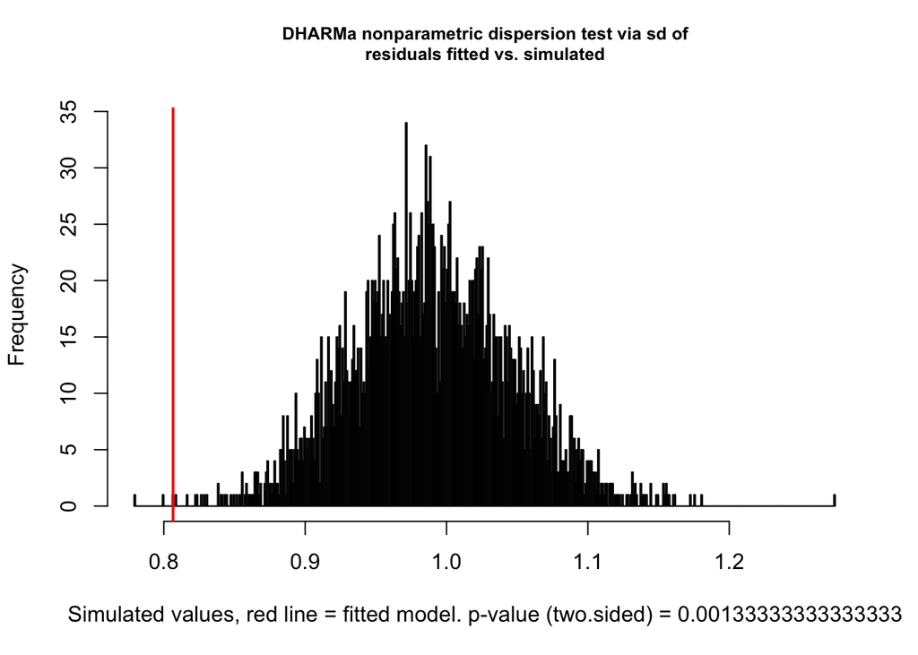

```
##
##  DHARMa nonparametric dispersion test via sd of residuals fitted vs.
##  simulated
##
## data:  simulationOutput
## dispersion = 0.81491, p-value = 0.001333
## alternative hypothesis: two.sided
```

```r
## The model actually predicts more dispersion than there is, signficantly so. This reduces power, but also reduces type 1 error. I won't be scaling standard errors here, as doing that is somewhat fraught in mixed models. If the betabinomial model had been able to fit the full random effects, it would likely resolve this.
testDispersion(sim_res)
```

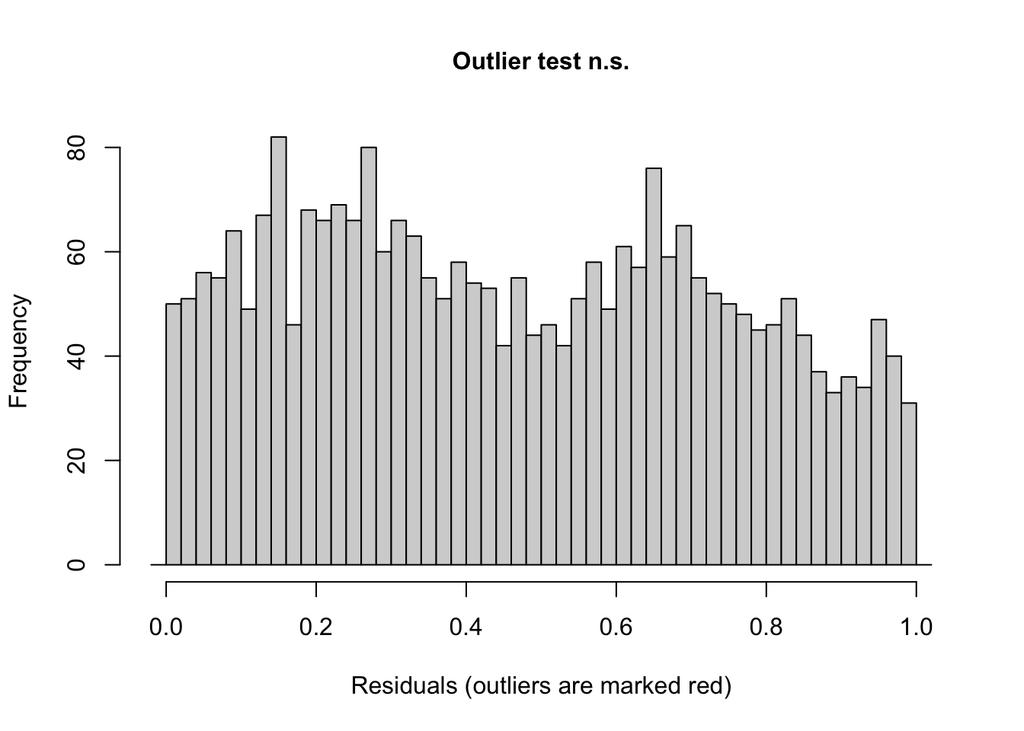

```
##
##  DHARMa outlier test based on exact binomial test with approximate
##  expectations
##
## data:  sim_res
## outliers at both margin(s) = 1, observations = 2683, p-value = 1
## alternative hypothesis: true probability of success is not equal to 0.0006664445
## 95 percent confidence interval:
##  9.436336e-06 2.074878e-03
## sample estimates:
## frequency of outliers (expected: 0.000666444518493835 )
##                                            0.0003727171
```

```r
## There aren't any more outliers in the data than expected
testOutliers(sim_res)
```

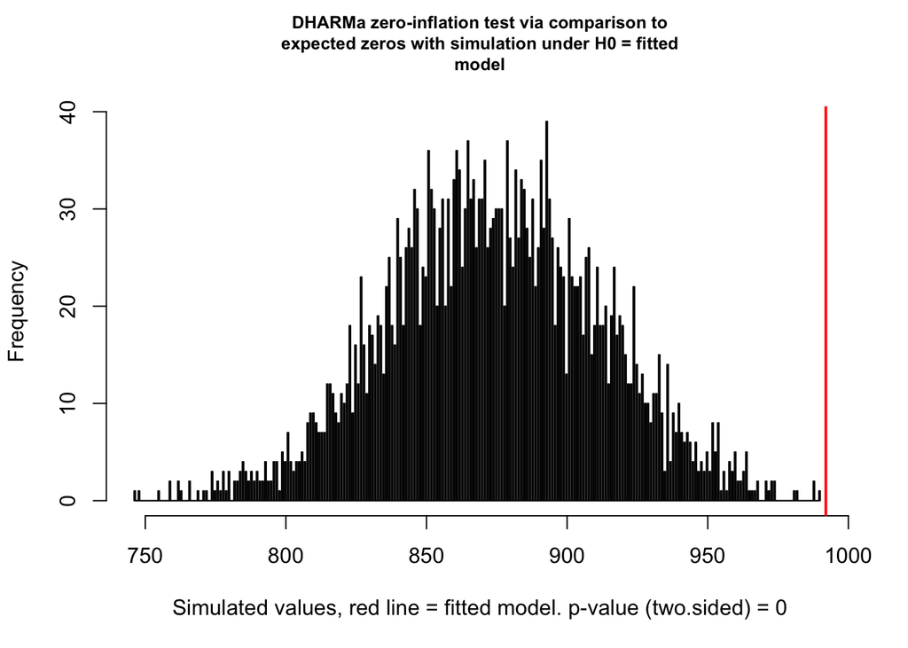

```
##
##  DHARMa zero-inflation test via comparison to expected zeros with
##  simulation under H0 = fitted model
##
## data:  simulationOutput
## ratioObsSim = 1.1351, p-value < 2.2e-16
## alternative hypothesis: two.sided
```

```r
## The model predicts signficantly less zeroes than observed in the dataset.
testZeroInflation(sim_res)
```

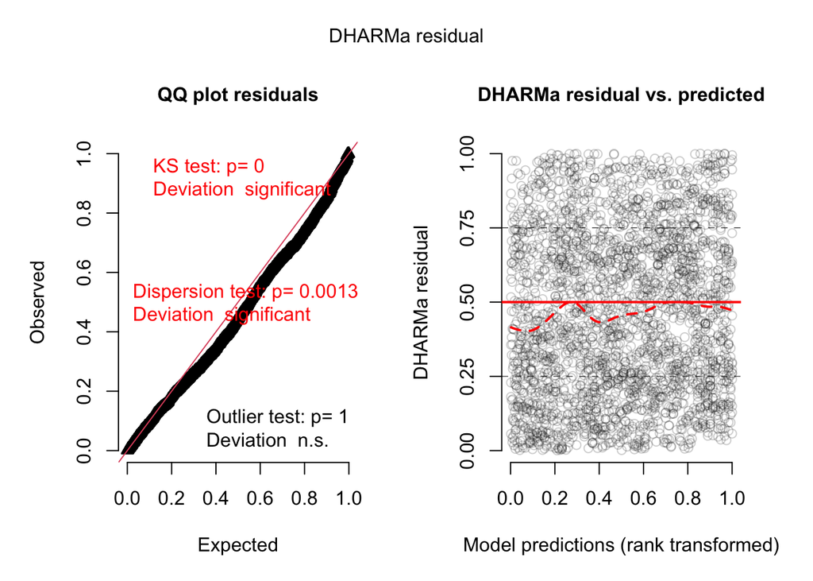

```r
## We'll see an easier on the eyes QQ plot soon. First, this shows that the model is significantly deviating from predictions.
plot(sim_res)
```

```r
library(performance)
check_predictions(best_binom_model)
```

```
## Ignoring unknown labels:
## • size : ""
```

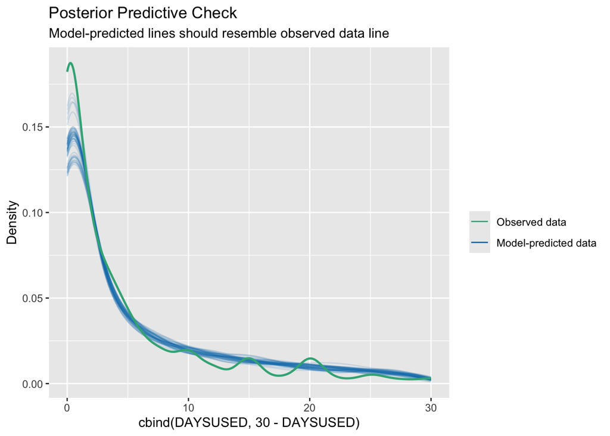

```r
df<- as.data.frame(check_predictions(best_binom_model))
table_obs <- table(df$y)
table_sim1 <- table(df$sim_1)
table_sim2 <- table(df$sim_2)
table_sim3 <- table(df$sim_3)

freq_table <- as.data.frame(cbind(
  Value = names(table_obs),
  Observed = as.vector(table_obs),
  Sim1 = as.vector(table_sim1),
  Sim2 = as.vector(table_sim2),
  Sim3 = as.vector(table_sim3)
))
(freq_table)
```

```
##    Value Observed Sim1 Sim2 Sim3
## 1      0      992  862  907  890
## 2      1      299  349  342  334
## 3      2      232  199  224  197
## 4      3      192  156  143  155
## 5      4      161  137  118  119
## 6      5      112   98  105  114
## 7      6       82   94   84  100
## 8      7       52   82   72   88
## 9      8       69   64   65   49
## 10     9       13   70   54   62
## 11    10      103   55   45   48
## 12    11        4   37   45   49
## 13    12       51   45   44   37
## 14    13        5   39   50   43
```

[output cut: 17 more lines]

```r
ranefs_binom <- ranef(best_binom_model)
```

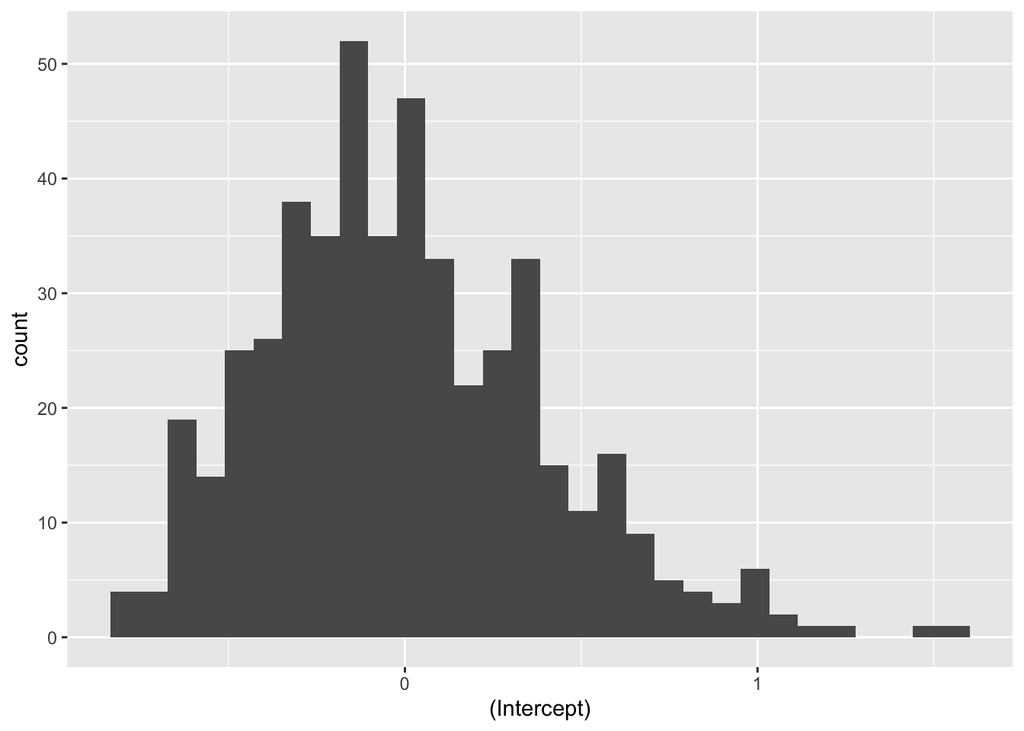

```r
ggplot(data = ranefs_binom$cond$PATNO, aes(x = `(Intercept)`)) +
    geom_histogram()
```

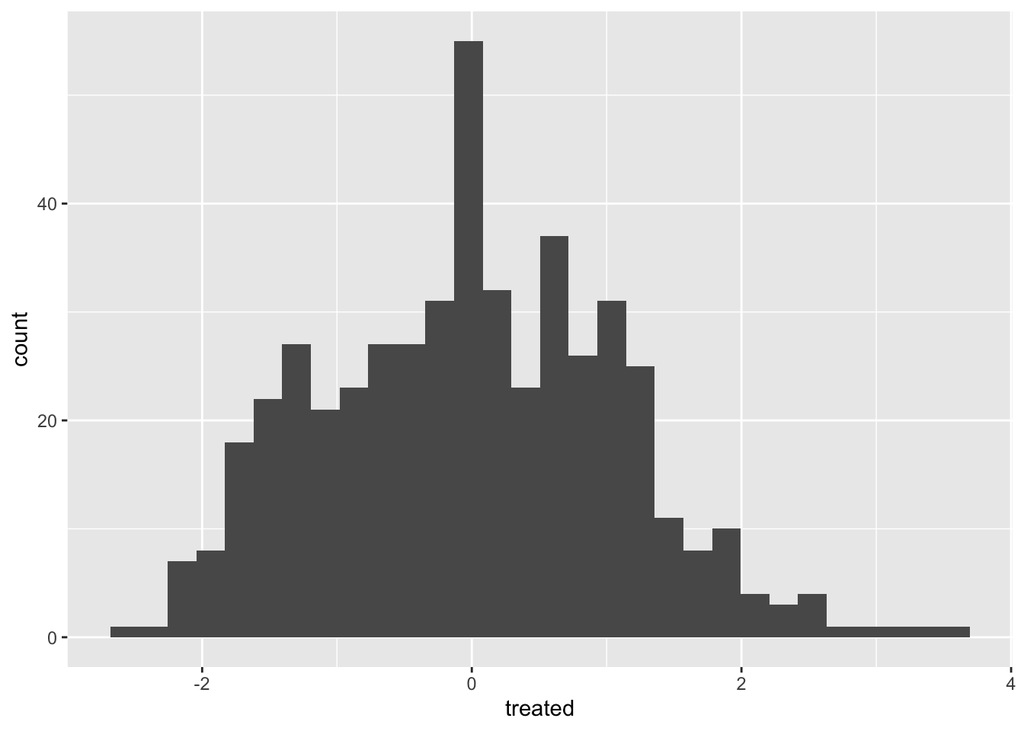

```r
ggplot(data = ranefs_binom$cond$PATNO, aes(x = treated)) +
    geom_histogram()
```

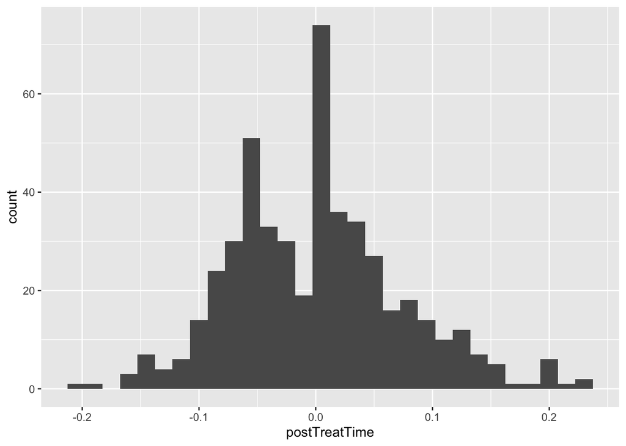

```r
ggplot(data = ranefs_binom$cond$PATNO, aes(x = postTreatTime)) +
    geom_histogram()
```

```r
library(car)
Anova(best_binom_model)
```

```
## Analysis of Deviance Table (Type II Wald chisquare tests)
##
## Response: cbind(DAYSUSED, 30 - DAYSUSED)
##                         Chisq Df Pr(>Chisq)
## TXNAME                 1.0907  3     0.7793
## treated              314.3413  1  < 2.2e-16 ***
## postTreatTime         16.5898  1   4.64e-05 ***
## SITE                   4.8048  4     0.3079
## TXNAME:treated         4.4659  3     0.2154
## TXNAME:postTreatTime   2.7426  3     0.4330
## ---
## Signif. codes:  0 '***' 0.001 '**' 0.01 '*' 0.05 '.' 0.1 ' ' 1
```

```r
print(1-pchisq(3.4659 + 2.7427,6))
```

```
## [1] 0.4002331
```

```r
print(1-pchisq(3.466 + 2.7427 + 1,0907,9))
```

```
## [1] 1
```

```r
binomtrends1 <- emtrends(best_binom_model, ~TXNAME, var ="treated")
binomtrends1
```

```
##  TXNAME treated.trend    SE  df asymp.LCL asymp.UCL
##  CT             -1.77 0.228 Inf     -2.22     -1.33
##  GDC            -2.24 0.232 Inf     -2.70     -1.79
##  IDC            -2.38 0.241 Inf     -2.86     -1.91
##  SE             -1.91 0.225 Inf     -2.35     -1.47
##
## Results are averaged over the levels of: treated, SITE
## Confidence level used: 0.95
```

```r
pairs(binomtrends1)
```

```
##  contrast  estimate    SE  df z.ratio p.value
##  CT - GDC     0.467 0.324 Inf   1.442  0.4730
##  CT - IDC     0.609 0.330 Inf   1.843  0.2533
##  CT - SE      0.134 0.319 Inf   0.420  0.9751
##  GDC - IDC    0.142 0.333 Inf   0.425  0.9741
##  GDC - SE    -0.333 0.322 Inf  -1.034  0.7295
##  IDC - SE    -0.475 0.329 Inf  -1.445  0.4713
##
## Results are averaged over the levels of: treated, SITE
## P value adjustment: tukey method for comparing a family of 4 estimates
```

```r
binomtrends2 <- emtrends(best_binom_model, ~TXNAME, var ="postTreatTime")
binomtrends2
```

```
##  TXNAME postTreatTime.trend     SE  df asymp.LCL asymp.UCL
##  CT                 -0.1088 0.0419 Inf    -0.191   -0.0267
##  GDC                -0.0595 0.0436 Inf    -0.145    0.0259
##  IDC                -0.1472 0.0475 Inf    -0.240   -0.0541
##  SE                 -0.0585 0.0423 Inf    -0.141    0.0244
##
## Results are averaged over the levels of: treated, SITE
## Confidence level used: 0.95
```

```r
pairs(binomtrends2)
```

```
##  contrast   estimate     SE  df z.ratio p.value
##  CT - GDC  -0.049337 0.0600 Inf  -0.823  0.8439
##  CT - IDC   0.038425 0.0628 Inf   0.612  0.9282
##  CT - SE   -0.050330 0.0591 Inf  -0.851  0.8297
##  GDC - IDC  0.087762 0.0639 Inf   1.373  0.5162
##  GDC - SE  -0.000992 0.0603 Inf  -0.016  1.0000
##  IDC - SE  -0.088755 0.0631 Inf  -1.407  0.4949
##
## Results are averaged over the levels of: treated, SITE
## P value adjustment: tukey method for comparing a family of 4 estimates
```

```r
summary(best_binom_model)
```

```
##  Family: binomial  ( logit )
## Formula:
## cbind(DAYSUSED, 30 - DAYSUSED) ~ TXNAME * (treated + postTreatTime) +
##     SITE + (treated + postTreatTime || PATNO) + ar1(0 + MONTH |      PATNO)
## Data: finalcoke
##
##       AIC       BIC    logLik -2*log(L)  df.resid
##   11629.3   11753.1   -5793.7   11587.3      2662
##
## Random effects:
##
## Conditional model:
##  Groups  Name          Variance Std.Dev. Corr
##  PATNO   (Intercept)   0.5981   0.7734
##          treated       2.6930   1.6410
##          postTreatTime 0.0346   0.1860
##  PATNO.1 MONTH0        1.5238   1.2344   0.41 (ar1)
## Number of obs: 2683, groups:  PATNO, 487
##
## Conditional model:
##                         Estimate Std. Error z value Pr(>|z|)
## (Intercept)             -0.80379    0.17751  -4.528 5.95e-06 ***
## TXNAMEGDC                0.21071    0.19690   1.070  0.28456
## TXNAMEIDC                0.16092    0.19806   0.812  0.41651
## TXNAMESE                 0.06081    0.19647   0.309  0.75694
## treated                 -1.77456    0.22781  -7.790 6.73e-15 ***
## postTreatTime           -0.10881    0.04188  -2.598  0.00938 **
## SITEMcLean              -0.36215    0.23725  -1.526  0.12689
## SITEMGH                  0.10330    0.20538   0.503  0.61500
## SITEPenn                -0.05881    0.17858  -0.329  0.74190
## SITEWPIC                -0.21381    0.17770  -1.203  0.22891
## TXNAMEGDC:treated       -0.46721    0.32399  -1.442  0.14929
## TXNAMEIDC:treated       -0.60893    0.33045  -1.843  0.06537 .
## TXNAMESE:treated        -0.13409    0.31946  -0.420  0.67467
## TXNAMEGDC:postTreatTime  0.04934    0.05998   0.823  0.41079
## TXNAMEIDC:postTreatTime -0.03843    0.06276  -0.612  0.54035
## TXNAMESE:postTreatTime   0.05033    0.05911   0.851  0.39451
## ---
## Signif. codes:  0 '***' 0.001 '**' 0.01 '*' 0.05 '.' 0.1 ' ' 1
```

```r
confint(best_binom_model)
```

```
##                                     2.5 %      97.5 %    Estimate
## (Intercept)                 -1.1517068639 -0.45588067 -0.80379377
## TXNAMEGDC                   -0.1752056183  0.59661743  0.21070591
## TXNAMEIDC                   -0.2272716722  0.54911533  0.16092183
## TXNAMESE                    -0.3242702164  0.44588481  0.06080730
## treated                     -2.2210718956 -1.32805557 -1.77456373
## postTreatTime               -0.1909010084 -0.02672098 -0.10881099
## SITEMcLean                  -0.8271387344  0.10284595 -0.36214639
## SITEMGH                     -0.2992425252  0.50583309  0.10329528
## SITEPenn                    -0.4088204618  0.29119326 -0.05881360
## SITEWPIC                    -0.5621012670  0.13448397 -0.21380865
## TXNAMEGDC:treated           -1.1022269923  0.16780096 -0.46721301
## TXNAMEIDC:treated           -1.2565876267  0.03873437 -0.60892663
## TXNAMESE:treated            -0.7602231862  0.49203496 -0.13409411
## TXNAMEGDC:postTreatTime     -0.0682303385  0.16690510  0.04933738
## TXNAMEIDC:postTreatTime     -0.1614271164  0.08457702 -0.03842505
## TXNAMESE:postTreatTime      -0.0655215829  0.16618083  0.05032963
## Std.Dev.(Intercept)|PATNO    0.6044554135  0.98946642  0.77336171
## Std.Dev.treated|PATNO        1.4457127546  1.86271638  1.64102189
## Std.Dev.postTreatTime|PATNO  0.1254432011  0.27580615  0.18600539
## Std.Dev.MONTH0|PATNO.1       1.1328730144  1.34507233  1.23442138
## Std.Dev.MONTH1|PATNO.1       1.1328730144  1.34507233  1.23442138
## Std.Dev.MONTH2|PATNO.1       1.1328730144  1.34507233  1.23442138
## Std.Dev.MONTH3|PATNO.1       1.1328730144  1.34507233  1.23442138
## Std.Dev.MONTH4|PATNO.1       1.1328730144  1.34507233  1.23442138
## Std.Dev.MONTH5|PATNO.1       1.1328730144  1.34507233  1.23442138
## Std.Dev.MONTH6|PATNO.1       1.1328730144  1.34507233  1.23442138
## Cor.MONTH1.MONTH0|PATNO.1    0.2920780752  0.50512487  0.40682010
## Cor.MONTH2.MONTH0|PATNO.1    0.0853096020  0.25515114  0.16550259
## Cor.MONTH3.MONTH0|PATNO.1    0.0249170643  0.12888318  0.06732978
## Cor.MONTH4.MONTH0|PATNO.1    0.0072777282  0.06510210  0.02739111
## Cor.MONTH5.MONTH0|PATNO.1    0.0021256648  0.03288469  0.01114325
## Cor.MONTH6.MONTH0|PATNO.1    0.0006208601  0.01661088  0.00453330
## Cor.MONTH2.MONTH1|PATNO.1    0.2920780752  0.50512487  0.40682010
## Cor.MONTH3.MONTH1|PATNO.1    0.0853096020  0.25515114  0.16550259
## Cor.MONTH4.MONTH1|PATNO.1    0.0249170643  0.12888318  0.06732978
## Cor.MONTH5.MONTH1|PATNO.1    0.0072777282  0.06510210  0.02739111
## Cor.MONTH6.MONTH1|PATNO.1    0.0021256648  0.03288469  0.01114325
## Cor.MONTH3.MONTH2|PATNO.1    0.2920780752  0.50512487  0.40682010
## Cor.MONTH4.MONTH2|PATNO.1    0.0853096020  0.25515114  0.16550259
## Cor.MONTH5.MONTH2|PATNO.1    0.0249170643  0.12888318  0.06732978
## Cor.MONTH6.MONTH2|PATNO.1    0.0072777282  0.06510210  0.02739111
## Cor.MONTH4.MONTH3|PATNO.1    0.2920780752  0.50512487  0.40682010
## Cor.MONTH5.MONTH3|PATNO.1    0.0853096020  0.25515114  0.16550259
## Cor.MONTH6.MONTH3|PATNO.1    0.0249170643  0.12888318  0.06732978
## Cor.MONTH5.MONTH4|PATNO.1    0.2920780752  0.50512487  0.40682010
## Cor.MONTH6.MONTH4|PATNO.1    0.0853096020  0.25515114  0.16550259
## Cor.MONTH6.MONTH5|PATNO.1    0.2920780752  0.50512487  0.40682010
```